# Ej04 sol

## Ejercicio 4

### El método de Birge-Vieta

Si tenemos el polinomio

$$P(x) = x^3-x^2-x-1$$

y aplicamos Ruffini

$$ \begin{array}{c|rrrrr} & 1 & -1 & -1 & -1 \\ -1 & & -1 & 2 & -1\\ \hline & 1 & -2 & 1 & \fbox{-2} \end{array} $$

Tenemos que $P(x) = Q(x)(x+1)-2$ por lo que $P(-1)= -2$. Si repetimos para $Q$

$$ \begin{array}{c|rrrr} & 1 & -2 & 1 \\ -1 & & -1 & 3 \\ \hline & 1 & -3 &\fbox{4} \end{array} $$

Como $P'(x)=Q'(x)(x+1)+Q(x)$ tenemos que $P'(-1)=Q(-1)=4$

Por lo tanto, dado un polinomio, si aplicamos Ruffini dos veces podremos calcular el valor del polinomio en un punto y también su derivada en ese punto.

Dado un polinomio, escribir una función **`valores(pol,x0)`** que tenga como entrada los coeficientes del polinomio en una lista, ordenados de mayor a menor grado **`pol`** y un punto **`x0`** y como salida el valor del polinomio y su derivada en dicho punto **`y0, dy0`**, obtenidos aplicando dos veces Ruffini. Utilizarlo para calcular la raíz mayor del polinomio por el método de Newton con condición de parada que la diferencia entre dos iteraciones consecutivas sea menor que $10^{-12}$. Dibujar el polinomio y la raíz como un punto rojo.

Aplicarlo a los polinomios

$$ P_1(x)= x^3-x^2-x-1 \quad P_2(x)= x^4-x-10 \quad P_3(x)= x^3-x+4$$

```python
%matplotlib inline
from __future__ import division
import numpy as np
import matplotlib.pyplot as plt
```

La función `ruffini` devuelve un vector.

```python
def ruffini(pol,x0):

    n = len(pol)
    b = np.zeros((n,))

    b[0] = pol[0]
    for i in range(1,n):
        b[i] = b[i-1]*x0 + pol[i]
    return b
```

El último elemento del vector es el valor que nos interesa. Por otra parte, el polinomio de entrada en la segunda vez, es el anterior menos el último elemento.

```python
def valores(pol,x0):

    b = ruffini(pol,x0)
    y0 = b[-1] # tomamo el último elemento de b

    c = ruffini(b[:-1],x0) # quitamos el último elemento de b en el argumento de entrada
    dy0 = c[-1] # tomamo el último elemento de c

    return (y0,dy0)
```

```
Raíz P1 =  1.83928675521
```

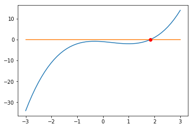

```
Raíz P2 =  1.85558452864
```

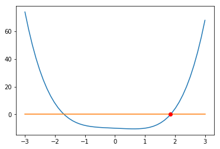

```
Raíz P3 =  -1.79632190326
```

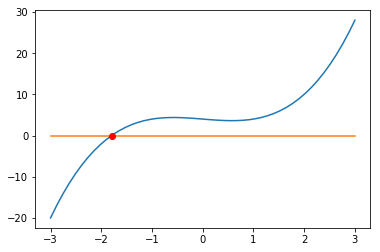

```python
polinomios = [[1,-1,-1,-1],[1,0,0,-1,-10],[1,0,-1,4]]
k = 1
for pol in polinomios:

    # Newton
    x0 = 3.
    error = 100
    while error > 1.e-12:
        y0, dy0 = valores(pol,x0)
        x1 = x0 - y0/dy0
        error = abs(x1-x0)
        x0 = x1

    # Print solución Newton
    print('Raíz P'+str(k)+' = ', x1)
    k += 1

    # Plot solución Newton
    x = np.linspace(-3,3)
    y = np.polyval(pol,x)
    plt.plot(x,y,x,x*0)
    plt.plot(x1,0,'ro')
    plt.show()
```